# Лабораторная работа №6

Дисциплина: Операционные системы

Савостин Олег

Российский университет дружбы народов, Москва, Россия

# Информация

## Докладчик

- Савостин Олег
- студент Физики-математического факультета, Математика и Механика.
- Российский университет дружбы народов
- 1032245472@pfur..ru

# Вводная часть

# Цель работы

Приобретение практических навыков взаимодействия пользователя с системой по- средством командной строки

# Задание

1. Базовые команды в терминале.

# Теоретическое введение

В операционной системе типа Linux взаимодействие пользователя с системой обычно осуществляется с помощью командной строки посредством построчного ввода ко- манд. При этом обычно используется командные интерпретаторы языка shell: /bin/sh; /bin/csh; /bin/ksh. Формат команды. Командой в операционной системе называется записанный по специальным правилам текст (возможно с аргументами), представляющий собой ука- зание на выполнение какой-либо функций (или действий) в операционной системе. Обычно первым словом идёт имя команды, остальной текст — аргументы или опции, конкретизирующие действие. Общий формат команд можно представить следующим образом: <имя_команды><разделитель><аргументы> Команда man. Команда man используется для просмотра (оперативная помощь) в диа- логовом режиме руководства (manual) по основным командам операционной системы типа Linux. Формат команды: man <команда> Пример (вывод информации о команде man): 1 man man Для управления просмотром результата выполнения команды man можно использовать следующие клавиши: – Space — перемещение по документу на одну страницу вперёд; – Enter — перемещение по документу на одну строку вперёд; – q — выход из режима просмотра описания. Команда cd. Команда cd используется для перемещения по файловой системе опера- ционной системы типа Linux. Замечание 1. Файловая система ОС типа Linux — иерархическая система каталогов, подкаталогов и файлов, которые обычно организованы и сгруппированы по функ- циональному признаку. Самый верхний каталог в иерархии называется корневым и обозначается символом /. Корневой каталог содержит системные файлы и другие каталоги

# Выполнение лабораторной работы

Перехожу в каталог tmp и смотрю файлы в нем. (рис. [-@fig:002]).

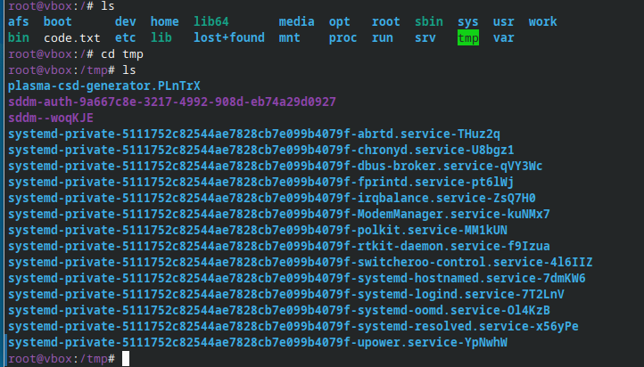

Файлы в соответствующем каталоге

Определяю если есть подкаталог cron (рис. [-@fig:003]).

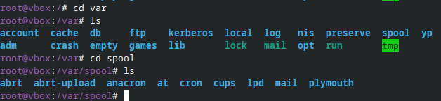

Cron

Перехожу в домашний каталог и вывожу на экран его содержимую Владелец - root, супер-пользователь (рис. [-@fig:004]).

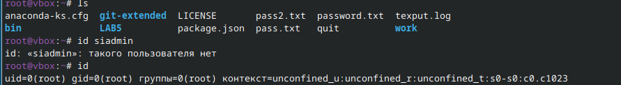

Домашний каталог

Создаю в домашнем каталоге новый каталог newdir и morefun(рис. [-@fig:005]).

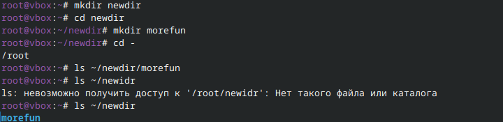

Новые каталоги

Создаю одной командой три каталога и одной командой их удаляю (рис. [-@fig:006]).

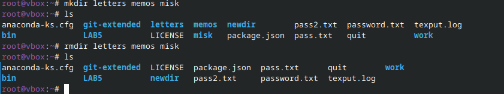

Каталоги

Удаляю ненужный каталог (рис. [-@fig:008]).

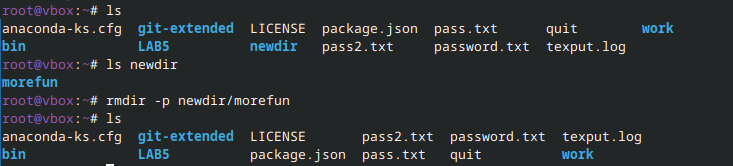

Удаление newdir

Определяю какую опцию нужно использовать чтобы просмотреть содержимое(рис. [-@fig:009]).

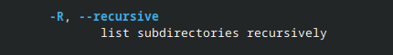

-R

Использую команду man для просмотра описания команд (рис. [-@fig:011]) (рис. [-@fig:012]) (рис. [-@fig:013]) (рис. [-@fig:014]) (рис. [-@fig:015]).

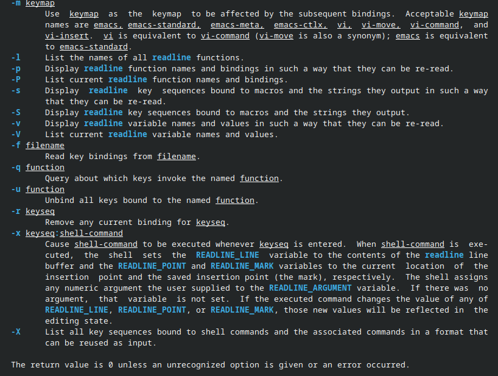

cd

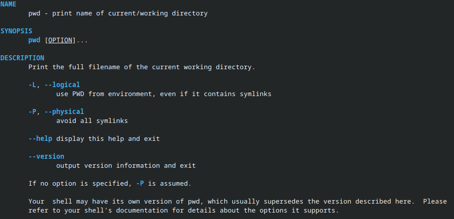

pwd

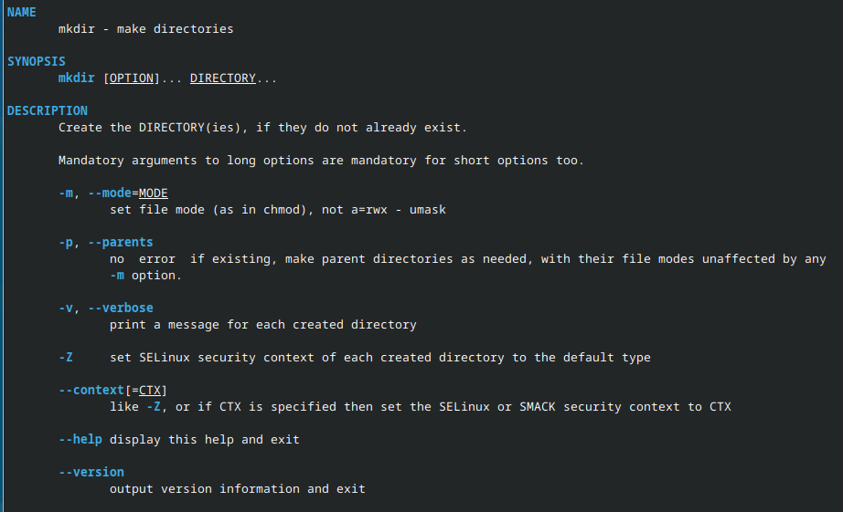

mkdir

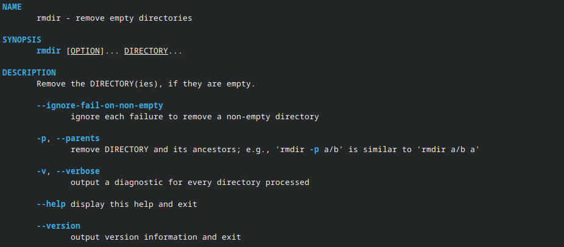

rmdir

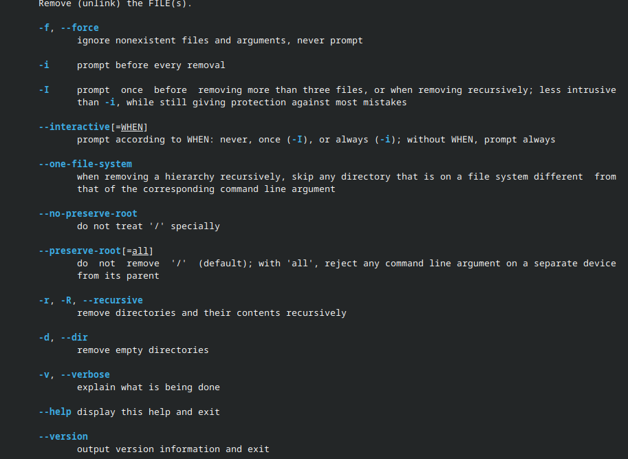

rm

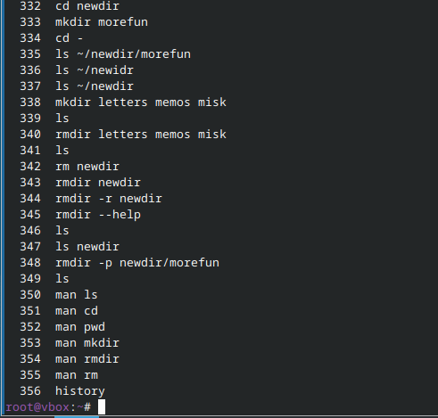

История

# Выводы

В ходе работы, я приобрел практических навыков взаимодействия пользователя с системой по- средством командной строки

# Список литературы